# K1_STAT_logistic_regression

Author

Duc Nguyen

Published

November 22, 2026

[**Tài liệu biên soạn trong chuyên đề R Statistics**](https://www.tuhocr.com/r-statistics)

[**Version final xem ở đây**](https://thongkevavedothi.com/blog/xac-suat-va-thong-ke/K1_STAT_logistic_regression.html)

# 1 Import dataset

```r
library(tidyverse)
library(gtregression)
library(dplyr)

data("data_diabetes_mediation",
     package = "gtregression")

# ?data_diabetes_mediation

data_diabetes_mediation -> df
```

# 2 Check dataset

```r
dim(df)
```

```
[1] 727   8
```

```r
summary(df)
```

```
 diabetes  obesity      glucose           bmi             age        blood_pressure    pregnancies    diabetes_pedigree
 No :462   No :262   Min.   : 57.0   Min.   :18.20   Min.   :21.00   Min.   : 24.00   Min.   : 0.00   Min.   :0.0780
 Yes:265   Yes:465   1st Qu.:101.0   1st Qu.:27.80   1st Qu.:24.00   1st Qu.: 64.00   1st Qu.: 1.00   1st Qu.:0.2450
                     Median :119.0   Median :32.80   Median :28.00   Median : 72.00   Median : 3.00   Median :0.3650
                     Mean   :125.4   Mean   :32.96   Mean   :33.29   Mean   : 72.58   Mean   : 4.67   Mean   :0.4790
                     3rd Qu.:144.0   3rd Qu.:37.15   3rd Qu.:41.00   3rd Qu.: 80.00   3rd Qu.: 7.00   3rd Qu.:0.6425
                     Max.   :196.0   Max.   :59.40   Max.   :81.00   Max.   :108.00   Max.   :13.00   Max.   :2.4200
```

```r
names(df)
```

```
[1] "diabetes"          "obesity"           "glucose"           "bmi"               "age"
[6] "blood_pressure"    "pregnancies"       "diabetes_pedigree"
```

# 3 Table summary

```r
df1 <- df

df1$diabetes <- factor(df1$diabetes,
                       levels = c("Yes", "No"))

df1$obesity <- factor(df1$obesity,
                       levels = c("Yes", "No"))
```

```r
library(table1)
library(flextable)
library(magrittr)
library(openxlsx)
library(dplyr)

table_freq <- table1:::table1.formula( ~ . | diabetes,
                     topclass="Rtable1-grid",
                     data = df1,
                    # digits = 4,
                    render.continuous = c("Mean (± SD)" = "MEAN (± SD)",
                                          "Median [Min, Max]" = "MEDIAN [MIN, MAX]")
                          )

table_freq
```

|  | Yes (N=265) | No (N=462) | Overall (N=727) |
| --- | --- | --- | --- |
| obesity |  |  |  |
| Yes | 206 (77.7%) | 259 (56.1%) | 465 (64.0%) |
| No | 59 (22.3%) | 203 (43.9%) | 262 (36.0%) |
| Plasma glucose |  |  |  |
| Mean (± SD) | 145 (± 30.8) | 114 (± 25.4) | 125 (± 31.3) |
| Median [Min, Max] | 146 [71.0, 196] | 111 [57.0, 194] | 119 [57.0, 196] |
| Body mass index |  |  |  |
| Mean (± SD) | 35.1 (± 6.79) | 31.7 (± 6.84) | 33.0 (± 7.01) |
| Median [Min, Max] | 34.0 [18.4, 59.4] | 31.6 [18.2, 57.3] | 32.8 [18.2, 59.4] |
| Age |  |  |  |
| Mean (± SD) | 36.7 (± 11.6) | 31.3 (± 12.0) | 33.3 (± 12.1) |
| Median [Min, Max] | 34.0 [21.0, 72.0] | 26.5 [21.0, 81.0] | 28.0 [21.0, 81.0] |
| Diastolic blood pressure |  |  |  |
| Mean (± SD) | 74.2 (± 12.0) | 71.6 (± 12.2) | 72.6 (± 12.2) |
| Median [Min, Max] | 74.0 [44.0, 106] | 72.0 [24.0, 108] | 72.0 [24.0, 108] |
| Number of pregnancies |  |  |  |
| Mean (± SD) | 5.68 (± 4.23) | 4.09 (± 3.52) | 4.67 (± 3.87) |
| Median [Min, Max] | 6.00 [0, 13.0] | 3.00 [0, 13.0] | 3.00 [0, 13.0] |
| Diabetes pedigree function |  |  |  |
| Mean (± SD) | 0.534 (± 0.416) | 0.447 (± 0.317) | 0.479 (± 0.359) |
| Median [Min, Max] | 0.400 [0.0880, 2.42] | 0.348 [0.0780, 2.33] | 0.365 [0.0780, 2.42] |

# 4 Compare groups | Raw OR

```r
library(compareGroups)

table_compare <- createTable(compareGroups(diabetes ~ .,
                                        data = df1,
                                        ref = 1,
                                        riskratio = FALSE,
                                        byrow = TRUE),
                          show.ratio = TRUE,
                          show.p.ratio = FALSE,
                          show.p.overall = TRUE)

table_compare
```

```
--------Summary descriptives table by 'diabetes'---------

_____________________________________________________________________________
                               Yes         No             OR        p.overall
                              N=265       N=462
¯¯¯¯¯¯¯¯¯¯¯¯¯¯¯¯¯¯¯¯¯¯¯¯¯¯¯¯¯¯¯¯¯¯¯¯¯¯¯¯¯¯¯¯¯¯¯¯¯¯¯¯¯¯¯¯¯¯¯¯¯¯¯¯¯¯¯¯¯¯¯¯¯¯¯¯¯
obesity:                                                             <0.001
    Yes                    206 (44.3%) 259 (55.7%)       Ref.
    No                     59 (22.5%)  203 (77.5%) 2.73 [1.95;3.87]
Plasma glucose             145 (30.8)  114 (25.4)  0.96 [0.96;0.97]  <0.001
Body mass index            35.1 (6.79) 31.7 (6.84) 0.93 [0.91;0.95]  <0.001
Age                        36.7 (11.6) 31.3 (12.0) 0.96 [0.95;0.98]  <0.001
Diastolic blood pressure   74.2 (12.0) 71.6 (12.2) 0.98 [0.97;1.00]   0.006
Number of pregnancies      5.68 (4.23) 4.09 (3.52) 0.90 [0.86;0.94]  <0.001
Diabetes pedigree function 0.53 (0.42) 0.45 (0.32) 0.52 [0.34;0.79]   0.003
¯¯¯¯¯¯¯¯¯¯¯¯¯¯¯¯¯¯¯¯¯¯¯¯¯¯¯¯¯¯¯¯¯¯¯¯¯¯¯¯¯¯¯¯¯¯¯¯¯¯¯¯¯¯¯¯¯¯¯¯¯¯¯¯¯¯¯¯¯¯¯¯¯¯¯¯¯
```

```r
# (206/259)/(59/203)
```

# 5 Correlation

```r
df_cor <- df

df_cor$diabetes <- factor(df_cor$diabetes ,
                       levels = c("No", "Yes"))

df_cor$obesity <- factor(df_cor$obesity,
                       levels = c("No", "Yes"))

df_cor$diabetes <- as.numeric(df_cor$diabetes) - 1

df_cor$obesity  <- as.numeric(df_cor$obesity ) - 1

library(rstatix)
library(corrplot)
# p-value
rstatix:::cor_pmat(df_cor,
                  method = "pearson") -> p_all

p_all <- as.data.frame(p_all)

row.names(p_all) <- p_all$rowname

p_all <- p_all[ , -1]

p_all <- as.matrix(p_all)
options(scipen = 6)
p_all
```

```
                  diabetes   obesity  glucose       bmi       age blood_pressure pregnancies diabetes_pedigree
diabetes          0.00e+00  3.23e-09 2.13e-43  2.30e-10  4.29e-09       5.95e-03    6.78e-08           0.00163
obesity           3.23e-09  0.00e+00 1.34e-03 1.57e-132  1.44e-01       8.64e-07    5.17e-01           0.37000
glucose           2.13e-43  1.34e-03 0.00e+00  2.72e-07  1.85e-08       1.47e-02    3.43e-06           0.04430
bmi               2.30e-10 1.57e-132 2.72e-07  0.00e+00  3.64e-01       7.05e-11    7.87e-01           0.10900
age               4.29e-09  1.44e-01 1.85e-08  3.64e-01  0.00e+00       4.10e-11   3.02e-126           0.13800
blood_pressure    5.95e-03  8.64e-07 1.47e-02  7.05e-11  4.10e-11       0.00e+00    6.11e-07           0.52500
pregnancies       6.78e-08  5.17e-01 3.43e-06  7.87e-01 3.02e-126       6.11e-07    0.00e+00           0.90000
diabetes_pedigree 1.63e-03  3.70e-01 4.43e-02  1.09e-01  1.38e-01       5.25e-01    9.00e-01           0.00000
```

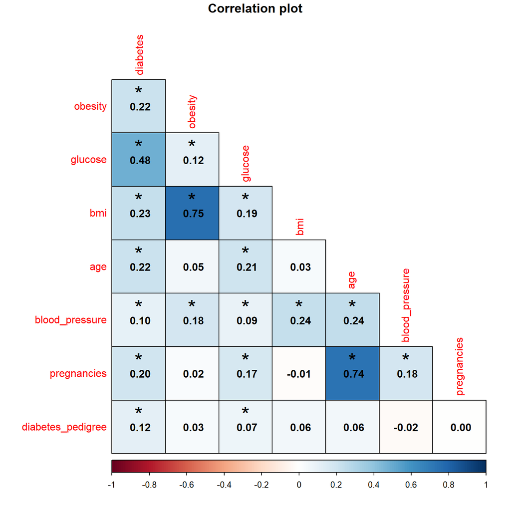

```r
# correlation
cor_m <- cor(df_cor)
par(pty = "s")
corrplot(cor_m,
         addCoef.col = "black",
           method = "color",
         type = "lower",
         diag = F,
         # col = viridis(100),
         p.mat = p_all,
         sig.level = 0.05,
         tl.col = 'red',
         insig = "label_sig",
         pch = "*
         ",
         title = "\nCorrelation plot",
         mar = c(0,0,0,0),
         addgrid.col = "black",
         outline = T,
         pch.cex =2
         # order = "hclust", # hierarchical clustering of correlations
         # addrect = 2
         )
```

# 6 Simple logistic regression | Crude OR

https://www.geo.fu-berlin.de/en/v/soga-r/Basics-of-statistics/Logistic-Regression/The-Logistic-Regression-Model/index.html

`diabetes` ~ `age`

$$\text{log(odds(Diabetes = 1))} = \text{log}\frac{\text{p(Diabetes = 1)}}{1-\text{p(Diabetes = 1)}} = logit(p)= \beta_0 + \beta_1 \times Age = \eta$$
$$logit(p) = \eta = \text{log}\frac{p}{1-p} \Rightarrow p = logit^{-1}(\eta) = \phi(\eta)= \frac{e^\eta}{1+e^{\eta}} = \frac{1}{1 + e^{-\eta}} = \frac{1}{1 + e^{-{(\beta_0 +\beta_1 \times Age)}}}$$
[The logit] **models** [the log odds] of [the outcome] as a linear combination of the predictors.

Mô hình logit (thuật toán logit) sẽ “mô hình hóa” các giá trị log odds của biến Y về dạng tuyến tính của các biến X.

**Tip**

Ví dụ: Xác suất để xảy ra sự kiện 1 (bị tiểu đường) của bệnh nhân thứ $i$ có độ tuổi là 55 ($x_i = 55$)

Bây giờ ta ráp code vào tính cụ thể.

```r
dg <- df

dg$diabetes <- factor(dg$diabetes ,
                       levels = c("No", "Yes"))

dg$obesity <- factor(dg$obesity,
                       levels = c("No", "Yes"))

dg$diabetes <- as.numeric(dg$diabetes) - 1

dg$obesity  <- as.numeric(dg$obesity ) - 1
```

**Ta sắp xếp bệnh nhân theo độ tuổi từ nhỏ đến lớn để thuận tiện vẽ đồ thị sau này.**

```r
dg |> dplyr:::arrange(age) -> dg
```

```r
fit1 <- glm(diabetes ~ age,
            data = dg,
            family = "binomial")

summary(fit1)
```

```
Call:
glm(formula = diabetes ~ age, family = "binomial", data = dg)

Coefficients:
            Estimate Std. Error z value Pr(>|z|)
(Intercept) -1.79248    0.23457  -7.642 2.15e-14 ***
age          0.03659    0.00648   5.647 1.64e-08 ***
---
Signif. codes:  0 '***' 0.001 '**' 0.01 '*' 0.05 '.' 0.1 ' ' 1

(Dispersion parameter for binomial family taken to be 1)

    Null deviance: 953.78  on 726  degrees of freedom
Residual deviance: 920.58  on 725  degrees of freedom
AIC: 924.58

Number of Fisher Scoring iterations: 4
```

```r
coef(fit1)
```

```
(Intercept)         age
-1.79248336  0.03658811
```

```r
exp(coef(fit1))
```

```
(Intercept)         age
  0.1665461   1.0372657
```

```r
fit1a <- glm(diabetes ~ age,
            data = dg,
            family = "gaussian")

summary(fit1a)
```

```
Call:
glm(formula = diabetes ~ age, family = "gaussian", data = dg)

Coefficients:
            Estimate Std. Error t value      Pr(>|t|)
(Intercept) 0.079023   0.051093   1.547         0.122
age         0.008576   0.001443   5.945 0.00000000429 ***
---
Signif. codes:  0 '***' 0.001 '**' 0.01 '*' 0.05 '.' 0.1 ' ' 1

(Dispersion parameter for gaussian family taken to be 0.2214837)

    Null deviance: 168.40  on 726  degrees of freedom
Residual deviance: 160.58  on 725  degrees of freedom
AIC: 971.25

Number of Fisher Scoring iterations: 2
```

```r
coef(fit1a)
```

```
(Intercept)         age
0.079023112 0.008576454
```

$$Y = \beta_0 + \beta_1 \times X$$

$p_i$ là xác suất xảy ra sự kiện 1 (Diabetes = Yes) của bệnh nhân thứ $i$

$$\text{log}\frac{p_i}{1-p_i} = \beta_0 + \beta_1 \times Age = -1.79248 + 0.03659 \times Age$$

$$\text{Odds Ratio của Age = OR(Age) =} e^{\beta_1} = e^{0.03659} = 1.0372657$$
**`predict()` sử dụng `type = "link"` sẽ trả về kết quả của phương trình còn ở dạng log, ta cần tính thủ công để tìm ra `p` là xác suất bị tiểu đường.**

```r
df_pred <- data.frame(age = 55)

pred1a <- predict(fit1,
                 newdata = df_pred,
                 type = "link")
pred1a
```

```
        1
0.2198625
```

```r
# log(p / (1-p)) = 0.2198
# ==> p / (1-p) = e^0.2198

ok1 <- exp(1)^0.2198

# p + 1.2458*p = 1.2458
# ==> p = 1.2458/(2.2458) = 0.55473
```

**Để thuận tiện, sử dụng `type = "response"` để cho ra trực tiếp kết quả xác suất bệnh tiểu đường khi bệnh nhân có độ tuổi là 55.**

```r
pred1b <- predict(fit1,
                 newdata = df_pred,
                 type = "response")
pred1b
```

```
        1
0.5547453
```

https://www.geo.fu-berlin.de/en/v/soga-r/Basics-of-statistics/Logistic-Regression/Logistic-Regression-in-R---An-Example/index.html

**Biện luận:**

The coefficient of `age` is 0.03659. Dấu của hệ số này dương, nghĩa là xác suất xảy ra bệnh tiểu đường sẽ tăng theo độ tuổi. Cụ thể, với khi độ tuổi tăng 1 đơn vị thì xác suất trung bình bệnh tiểu đường (the log-odd) tăng lên 1 hằng số là 0.03659 đơn vị.

By taking the exponent of the coefficient value, we get the odds ratio của `age` là 1.0372

Nghĩa là, khi độ tuổi tăng 1 đơn vị thì odds ratio/“proability” (của sự kiện bị tiểu đường) tăng lên một tỷ lệ là 1.0372 - 1 = 0.03 = 3%.

**TipNote**

OR của biến numeric `age` trong bảng compare group này chính là kết quả của model logistic, với outcome `diabetes` đi theo thứ tự level được quy định.

**Yes = 0 ; No = 1**

```r
library(compareGroups)

table_compare <- createTable(compareGroups(diabetes ~ .,
                                        data = df1[ , c("diabetes", "age")],
                                        ref = 1,
                                        riskratio = FALSE,
                                        byrow = TRUE),
                          show.ratio = TRUE,
                          show.p.ratio = FALSE,
                          show.p.overall = TRUE)

table_compare
```

```
--------Summary descriptives table by 'diabetes'---------

______________________________________________________
        Yes         No             OR        p.overall
       N=265       N=462
¯¯¯¯¯¯¯¯¯¯¯¯¯¯¯¯¯¯¯¯¯¯¯¯¯¯¯¯¯¯¯¯¯¯¯¯¯¯¯¯¯¯¯¯¯¯¯¯¯¯¯¯¯¯
Age 36.7 (11.6) 31.3 (12.0) 0.96 [0.95;0.98]  <0.001
¯¯¯¯¯¯¯¯¯¯¯¯¯¯¯¯¯¯¯¯¯¯¯¯¯¯¯¯¯¯¯¯¯¯¯¯¯¯¯¯¯¯¯¯¯¯¯¯¯¯¯¯¯¯
```

**No = 0 ; Yes = 1**

```r
library(compareGroups)

df1$diabetes <- factor(df1$diabetes,
                       levels = c("No", "Yes"))

table_compare <- createTable(compareGroups(diabetes ~ .,
                                        data = df1[ , c("diabetes", "age")],
                                        ref = 1,
                                        riskratio = FALSE,
                                        byrow = TRUE),
                          show.ratio = TRUE,
                          show.p.ratio = FALSE,
                          show.p.overall = TRUE)

table_compare
```

```
--------Summary descriptives table by 'diabetes'---------

______________________________________________________
        No          Yes            OR        p.overall
       N=462       N=265
¯¯¯¯¯¯¯¯¯¯¯¯¯¯¯¯¯¯¯¯¯¯¯¯¯¯¯¯¯¯¯¯¯¯¯¯¯¯¯¯¯¯¯¯¯¯¯¯¯¯¯¯¯¯
Age 31.3 (12.0) 36.7 (11.6) 1.04 [1.02;1.05]  <0.001
¯¯¯¯¯¯¯¯¯¯¯¯¯¯¯¯¯¯¯¯¯¯¯¯¯¯¯¯¯¯¯¯¯¯¯¯¯¯¯¯¯¯¯¯¯¯¯¯¯¯¯¯¯¯
```

## 6.1 Predict

### 6.1.1 Outcome quy về xác suất

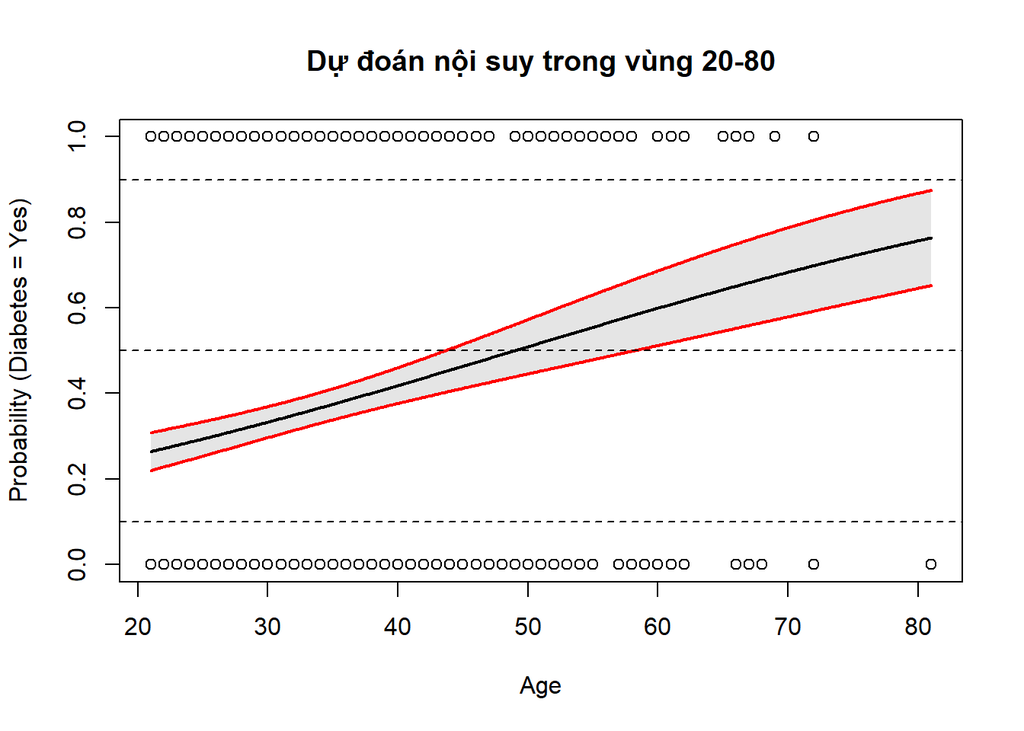

```r
ages <- seq(min(dg$age),
            max(dg$age),
            by = 0.1)

probs <- predict(fit1,
  newdata = data.frame(age = ages),
  type = "response",
  se.fit = TRUE
)

pm <- probs$fit
pu <- probs$fit + probs$se.fit * 1.96 # 95% confidence interval
pl <- probs$fit - probs$se.fit * 1.96 # 95% confidence interval

plot(x = dg$age,
     y = dg$diabetes,
  pch = 1,
  cex = 1,
  ylab = "Probability (Diabetes = Yes)",
  xlab = "Age",
  main = "Dự đoán nội suy trong vùng 20-80"
)

polygon(c(rev(ages), ages), c(rev(pl), pu),
  col = "grey90", border = NA
)

lines(ages, pm, lwd = 2)
lines(ages, pu, lwd = 2, col = "red")
lines(ages, pl, lwd = 2, col = "red")

abline(h = 0.1, lty = 2)
abline(h = 0.5, lty = 2)
abline(h = 0.9, lty = 2)
```

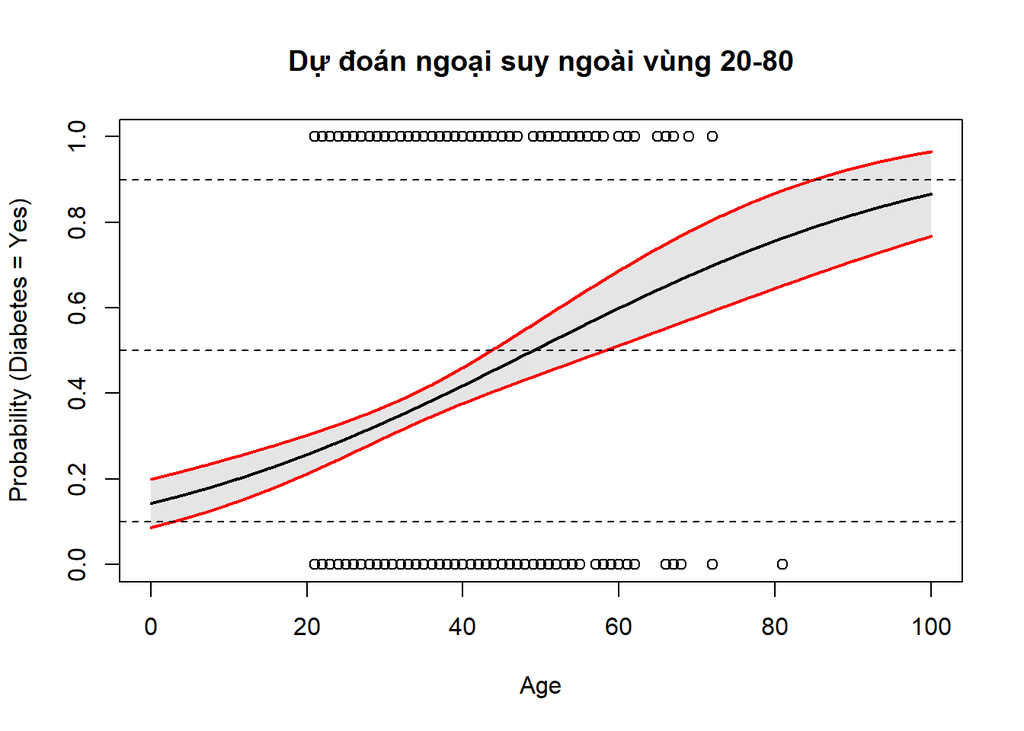

```r
ages <- seq(0,
            100,
            by = 0.1)

probs <- predict(fit1,
  newdata = data.frame(age = ages),
  type = "response",
  se.fit = TRUE
)

pm <- probs$fit
pu <- probs$fit + probs$se.fit * 1.96 # 95% confidence interval
pl <- probs$fit - probs$se.fit * 1.96 # 95% confidence interval

plot(x = dg$age,
     y = dg$diabetes,
  pch = 1,
  cex = 1,
  ylab = "Probability (Diabetes = Yes)",
  xlab = "Age",
  xlim = c(0, 100),  ,
  main = "Dự đoán ngoại suy ngoài vùng 20-80"
)

polygon(c(rev(ages), ages), c(rev(pl), pu),
  col = "grey90", border = NA
)

lines(ages, pm, lwd = 2)
lines(ages, pu, lwd = 2, col = "red")
lines(ages, pl, lwd = 2, col = "red")

abline(h = 0.1, lty = 2)
abline(h = 0.5, lty = 2)
abline(h = 0.9, lty = 2)
```

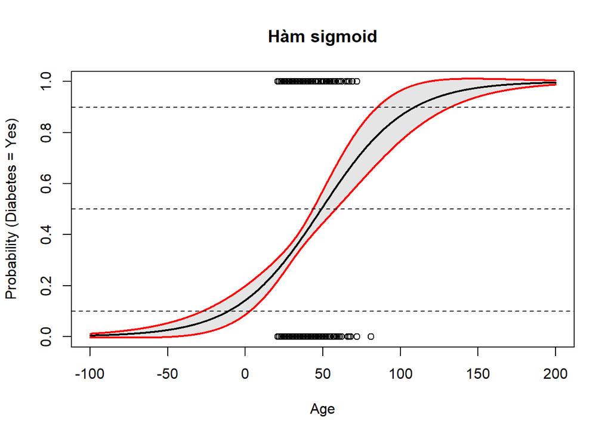

```r
ages <- seq(-100,
            200,
            by = 0.1)

probs <- predict(fit1,
  newdata = data.frame(age = ages),
  type = "response",
  se.fit = TRUE
)

pm <- probs$fit
pu <- probs$fit + probs$se.fit * 1.96 # 95% confidence interval
pl <- probs$fit - probs$se.fit * 1.96 # 95% confidence interval

plot(x = dg$age,
     y = dg$diabetes,
  pch = 1,
  cex = 1,
  ylab = "Probability (Diabetes = Yes)",
  xlab = "Age",
  xlim = c(-100, 200),  ,
  main = "Hàm sigmoid"
)

polygon(c(rev(ages), ages), c(rev(pl), pu),
  col = "grey90", border = NA
)

lines(ages, pm, lwd = 2)
lines(ages, pu, lwd = 2, col = "red")
lines(ages, pl, lwd = 2, col = "red")

abline(h = 0.1, lty = 2)
abline(h = 0.5, lty = 2)
abline(h = 0.9, lty = 2)
```

### 6.1.2 Outcome quy về log odds

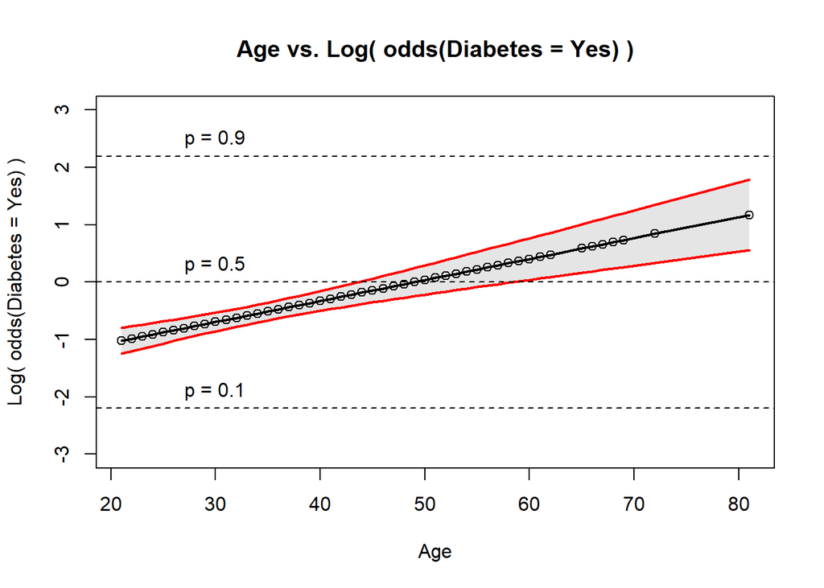

```r
ages <- dg$age

probs <- predict(fit1,
  newdata = data.frame(age = ages),
  type = "link",
  se.fit = TRUE
)

pm <- probs$fit
pu <- probs$fit + probs$se.fit * 1.96 # 95% confidence interval
pl <- probs$fit - probs$se.fit * 1.96 # 95% confidence interval

plot(x = dg$age,
     y = pm,
  pch = 1,
  cex = 1,
  ylab = "Log( odds(Diabetes = Yes) )",
  xlab = "Age",
  main = "Age vs. Log( odds(Diabetes = Yes) )",
  ylim = c(-3, 3)
)



polygon(c(rev(ages), ages), c(rev(pl), pu),
  col = "grey90", border = NA
)

lines(ages, pm, lwd = 2)
lines(ages, pu, lwd = 2, col = "red")
lines(ages, pl, lwd = 2, col = "red")

abline(h = log(0.1/(1-0.1)), lty = 2)

abline(h = log(0.5/(1-0.5)), lty = 2)
abline(h = log(0.9/(1-0.9)), lty = 2)

points(x = dg$age,
       y = pm,
       pch = 1,
       cex = 1)

text(x = 30,
     y = log(0.1/(1-0.1)),
     label = "p = 0.1",
     pos = 3)

text(x = 30,
     y = log(0.5/(1-0.5)),
     label = "p = 0.5",
     pos = 3)

text(x = 30,
     y = log(0.9/(1-0.9)),
     label = "p = 0.9",
     pos = 3)
```

## 6.2 Effect plot

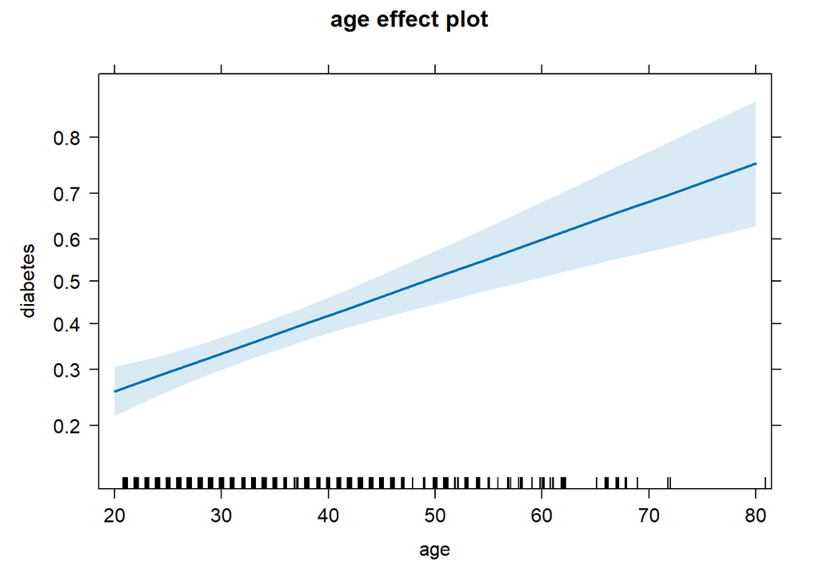

```r
library(effects)
library(cowplot)
library(grid)
library(gridExtra)
library(lattice)
library(latticeExtra)

fit1_ok <- allEffects(fit1)

fit1_eff <- effects:::plot.efflist(x = fit1_ok,
                            selection = "age",
                            axes = list(y = list(lim = c(-2, 2)),
                                        x = list(rotate = 0))
                            )


plot_grid(fit1_eff)
```

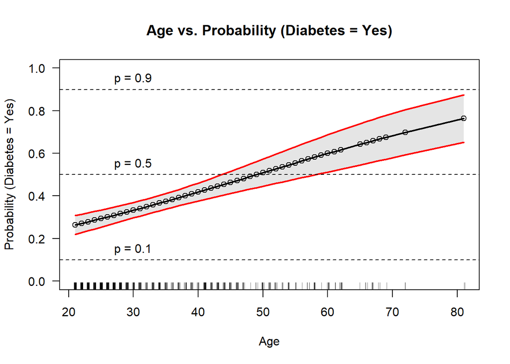

```r
ages <- dg$age

probs <- predict(fit1,
  newdata = data.frame(age = ages),
  type = "response",
  se.fit = TRUE
)

pm <- probs$fit
pu <- probs$fit + probs$se.fit * 1.96 # 95% confidence interval
pl <- probs$fit - probs$se.fit * 1.96 # 95% confidence interval

plot(x = dg$age,
     y = pm,
     las = 1,
  pch = 1,
  cex = 1,
  ylim = c(0, 1),
  ylab = "Probability (Diabetes = Yes)",
  xlab = "Age",
  main = "Age vs. Probability (Diabetes = Yes)"
)




polygon(c(rev(ages), ages), c(rev(pl), pu),
  col = "grey90", border = NA
)

lines(ages, pm, lwd = 2)
lines(ages, pu, lwd = 2, col = "red")
lines(ages, pl, lwd = 2, col = "red")

abline(h = 0.1, lty = 2)

abline(h = 0.5, lty = 2)
abline(h = 0.9, lty = 2)

points(x = dg$age,
       y = pm,
       pch = 1,
       cex = 1)

text(x = 30,
     y = 0.1,
     label = "p = 0.1",
     pos = 3)

text(x = 30,
     y = 0.5,
     label = "p = 0.5",
     pos = 3)

text(x = 30,
     y = 0.9,
     label = "p = 0.9",
     pos = 3)

rug(jitter(dg$age),
    col = adjustcolor(col = "black",
                      alpha.f = 0.5))

box()
```

## 6.3 Model validation

```r
library(performance)
library(see)

# 1. Model performance
performance::model_performance(fit1)
```

```
# Indices of model performance

AIC   |  AICc |   BIC | Tjur's R2 |  RMSE | Sigma | Log_loss | Score_log | Score_spherical |   PCP
--------------------------------------------------------------------------------------------------
924.6 | 924.6 | 933.8 |     0.045 | 0.471 |     1 |    0.633 |  -122.585 |           0.004 | 0.558
```

```r
# 2. Predictive accuracy (ROC-AUC)
performance::performance_accuracy(
  fit1,
  method = "cv",
  k = 5
)
```

```
# Accuracy of Model Predictions

Accuracy (95% CI): 67.20% [63.01%, 71.65%]
Method: Area under Curve
```

```r
# 3. Check residual distribution
performance::check_residuals(fit1)
```

```
OK: Simulated residuals appear as uniformly distributed (p = 0.592).
```

```r
# 4. Check multicollinearity
# performance::check_collinearity(fit1)

# 5. Check autocorrelation
performance::check_autocorrelation(fit1)
```

```
OK: Residuals appear to be independent and not autocorrelated (p = 0.270).
```

```r
# 6. Check outliers
performance::check_outliers(fit1)
```

```
OK: No outliers detected.
- Based on the following method and threshold: cook (0.5).
- For variable: (Whole model)
```

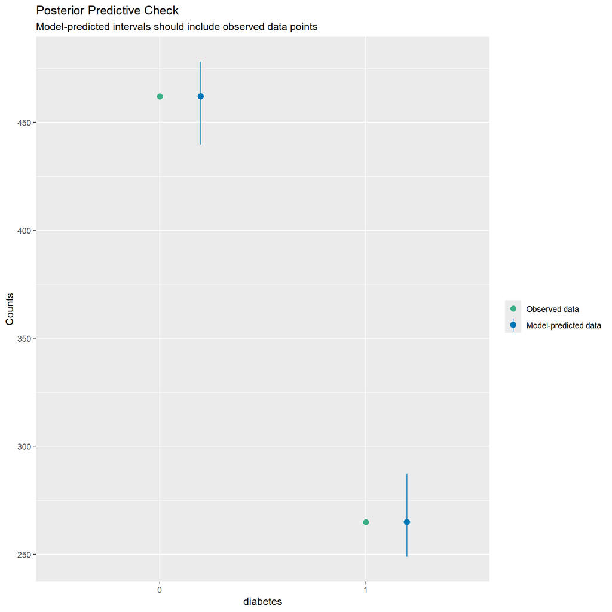

```r
# 7. Check binned residuals
performance::binned_residuals(fit1)
# 8. Check predictions
performance::check_predictions(fit1)
```

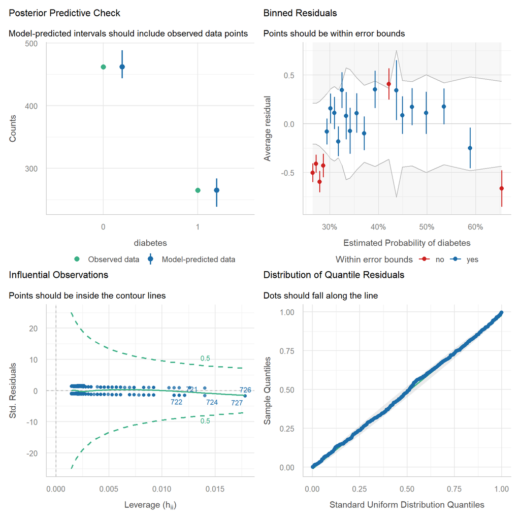

```r
# 9. Overall diagnostic plots
performance::check_model(fit1)
```

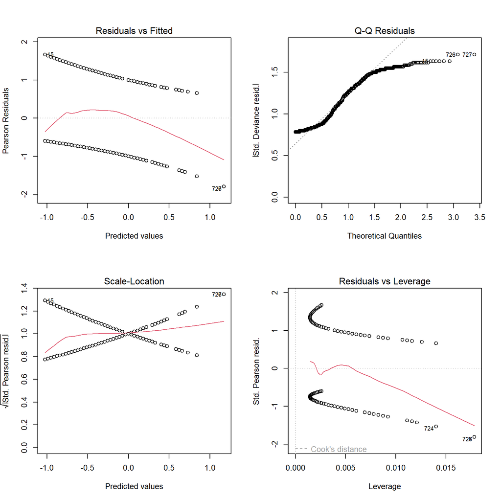

```r
par(mfrow = c(2,2))
plot(fit1)
```

## 6.4 ROC | Cut-off threshold

```r
library(pROC)

probs_check <- predict(fit1,
                 type = "response")

roc_check <- pROC:::roc(response = dg$diabetes,
                   predictor = probs_check,
                   auc = TRUE,
                   ci = TRUE)

roc_check
```

```
Call:
roc.default(response = dg$diabetes, predictor = probs_check,     auc = TRUE, ci = TRUE)

Data: probs_check in 462 controls (dg$diabetes 0) < 265 cases (dg$diabetes 1).
Area under the curve: 0.6727
95% CI: 0.6334-0.7119 (DeLong)
```

```r
roc_check$auc
```

```
Area under the curve: 0.6727
```

```r
dg -> dh

dh$probs_check <- probs_check
```

```r
library(verification)
verification:::roc.area(obs = dg$diabetes,
                        pred = probs_check)
```

```
$A
[1] 0.6726538

$n.total
[1] 727

$n.events
[1] 265

$n.noevents
[1] 462

$p.value
[1] 4.050859e-15
```

```r
optimal_cutoff <- pROC:::coords(roc_check,
                         "best",
                         best.method = "youden")

optimal_cutoff
```

```
  threshold specificity sensitivity
1 0.2974608   0.4458874   0.8377358
```

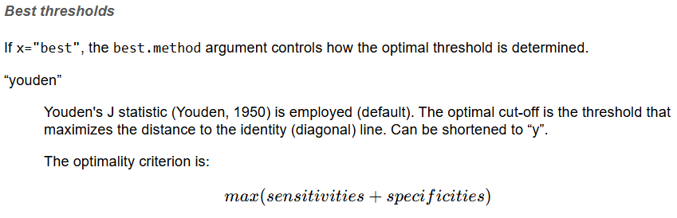

### 6.4.1 package `pROC`

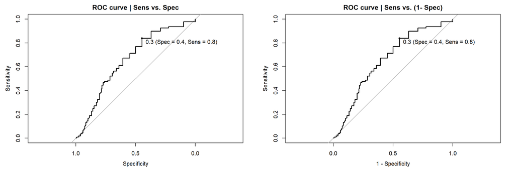

```r
par(mfrow = c(1,2))

pROC:::plot.roc(roc_check,
     print.thres = optimal_cutoff$threshold,
     type = "S",
     print.thres.pattern = "%.1f (Spec = %.1f, Sens = %.1f)",
     print.thres.cex = 1,
     legacy.axes = F,
     main = "ROC curve | Sens vs. Spec")

pROC:::plot.roc(roc_check,
     print.thres = optimal_cutoff$threshold,
     type = "S",
     print.thres.pattern = "%.1f (Spec = %.1f, Sens = %.1f)",
     print.thres.cex = 1,
     legacy.axes = T,
     main = "ROC curve | Sens vs. (1- Spec)")
```

### 6.4.2 package `ROCR`

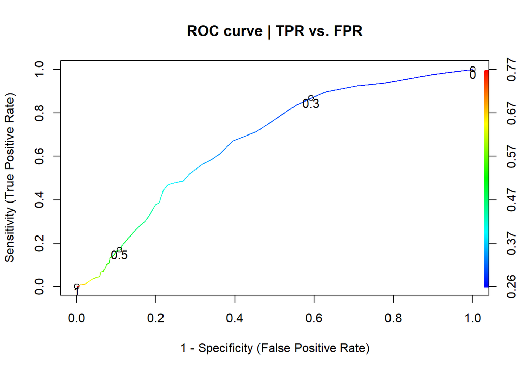

```r
library(ROCR)

perf <- ROCR:::performance(prediction(predictions = probs_check,
                                      labels = dg$diabetes),
                    "tpr",
                    "fpr")

ROCR:::plot.performance(perf,
            colorize = TRUE,
            print.cutoffs.at = c(0,optimal_cutoff$threshold, 0.5,1),
            text.adj=c(0.5, 1),
            ylab = "Sensitivity (True Positive Rate)",
            xlab = "1 - Specificity (False Positive Rate)",
            main = "ROC curve | TPR vs. FPR")
```

## 6.5 Confusion matrix

```r
dg$probs_check <- probs_check

dg$pred <- ifelse(test = dg$probs_check > optimal_cutoff$threshold,
                       yes = 1,
                       no = 0)

table(pred = dg$pred,
      ref = dg$diabetes) -> kq

kq <- kq[2:1, 2:1]

kq
```

```
    ref
pred   1   0
   1 222 256
   0  43 206
```

```r
library(epiR)
epiR:::epi.tests(kq, digits = 4)
```

```
          Outcome +    Outcome -      Total
Test +          222          256        478
Test -           43          206        249
Total           265          462        727

Point estimates and 95% CIs:
--------------------------------------------------------------
Apparent prevalence *                  0.6575 (0.6217, 0.6920)
True prevalence *                      0.3645 (0.3294, 0.4007)
Sensitivity *                          0.8377 (0.7877, 0.8800)
Specificity *                          0.4459 (0.4000, 0.4925)
Positive predictive value *            0.4644 (0.4190, 0.5103)
Negative predictive value *            0.8273 (0.7745, 0.8721)
Positive likelihood ratio              1.5119 (1.3715, 1.6666)
Negative likelihood ratio              0.3639 (0.2718, 0.4872)
False T+ proportion for true D- *      0.5541 (0.5075, 0.6000)
False T- proportion for true D+ *      0.1623 (0.1200, 0.2123)
False T+ proportion for T+ *           0.5356 (0.4897, 0.5810)
False T- proportion for T- *           0.1727 (0.1279, 0.2255)
Correctly classified proportion *      0.5887 (0.5520, 0.6248)
--------------------------------------------------------------
* Exact CIs
```

```r
library(caret)

caret::confusionMatrix(reference = factor(dg$diabetes,
                                          levels = c(1,0)), #thuc nghiem
                       data = factor(dg$pred,
                                       levels = c(1,0)),  #tien luong,
                       positive = "1",
                       mode = "everything")
```

```
Confusion Matrix and Statistics

          Reference
Prediction   1   0
         1 222 256
         0  43 206

               Accuracy : 0.5887
                 95% CI : (0.552, 0.6248)
    No Information Rate : 0.6355
    P-Value [Acc > NIR] : 0.9959

                  Kappa : 0.2421

 Mcnemar's Test P-Value : <2e-16

            Sensitivity : 0.8377
            Specificity : 0.4459
         Pos Pred Value : 0.4644
         Neg Pred Value : 0.8273
              Precision : 0.4644
                 Recall : 0.8377
                     F1 : 0.5976
             Prevalence : 0.3645
         Detection Rate : 0.3054
   Detection Prevalence : 0.6575
      Balanced Accuracy : 0.6418

       'Positive' Class : 1
```

## 6.6 Cut-off biến X

Ở thời điểm này biến `age` là numeric, ta có nhu cầu muốn tìm ra ngưỡng cut-off của `age` để thuận tiện dự báo rằng nếu 1 người nào đó trên độ tuổi nhất định thì khả năng cao sẽ bị tiểu đường.

Kết quả cutoff cho thấy nếu chia tuổi ra 2 nhóm:

- Nhóm 1: nhỏ hơn 26 (ít bị tiểu đường)
- Nhóm 2: lớn hơn 26 (dễ bị tiểu đường)

Ta sẽ xây dựng model logistic regression dựa trên biến `age_group_26` này và thu được kết quả sens, spec tương ứng.

Về bản chất thuật toán này sẽ tự động chia biến `age` thành 2 nhóm khác nhau (theo cut-off của độ tuổi) sau đó thực hiện model logistic đơn biến. Ứng với mỗi phương án cut-off sẽ có kết quả sens và spec khác nhau, phương án cut-off tối ưu là maximum sens và spec (theo method Youden) thì kết quả sẽ đề xuất ngưỡng cut-off đó.

```r
library(pROC)
library(OptimalCutpoints)
# Find cut-off with OptimalCutpoints package
optimal.cutpoint.Youden <- optimal.cutpoints(X = "age",
                                            status = "diabetes",
                                            tag.healthy = '0',
                                            methods = "Youden",
                                            data = dg
                                            )

summary(optimal.cutpoint.Youden)
```

```
Call:
optimal.cutpoints.default(X = "age", status = "diabetes", tag.healthy = "0",
    methods = "Youden", data = dg)

Area under the ROC curve (AUC):  0.673 (0.633, 0.712)

CRITERION: Youden
Number of optimal cutoffs: 1

                     Estimate
cutoff             26.0000000
Se                  0.8377358
Sp                  0.4458874
PPV                 0.4644351
NPV                 0.8273092
DLR.Positive        1.5118514
DLR.Negative        0.3639128
FP                256.0000000
FN                 43.0000000
Optimal criterion   0.2836233
```

### 6.6.1 Check lại kết quả

Kết quả này y chang như model `age` là numeric ở trên (vì cũng là đơn biến), tuy nhiên nếu đưa vào model đa biến thì kết quả sẽ khác.

Ban đầu:

Y ~ age(numeric) + gender

Sau khi biết cut-off tối ưu của `age`, ta có:

Y ~ age(category) + gender

Cách tiếp cận cut-off này giúp thuận tiện chuyển một biến numeric thành biến phân loại, giúp đơn giản hóa bảng khảo sát thông tin vì phân loại nhanh chóng mức độ bị tiểu đường theo tuổi.

Ví dụ ta hỏi bệnh nhân là 30 tuổi (lớn hơn ngưỡng cut-off là 26), thì cột `age_group` sẽ là 1, thuộc nhóm dễ bị tiểu đường.

```r
dg$age_group_26 <- ifelse(test = dg$age >= 26,
                          yes = 1,
                          no = 0)

fit2 <- glm(diabetes ~ age_group_26,
            data = dg,
            family = "binomial")

summary(fit2)
```

```
Call:
glm(formula = diabetes ~ age_group_26, family = "binomial", data = dg)

Coefficients:
             Estimate Std. Error z value Pr(>|z|)
(Intercept)   -1.5667     0.1676  -9.345  < 2e-16 ***
age_group_26   1.4242     0.1911   7.453 9.14e-14 ***
---
Signif. codes:  0 '***' 0.001 '**' 0.01 '*' 0.05 '.' 0.1 ' ' 1

(Dispersion parameter for binomial family taken to be 1)

    Null deviance: 953.78  on 726  degrees of freedom
Residual deviance: 889.37  on 725  degrees of freedom
AIC: 893.37

Number of Fisher Scoring iterations: 3
```

```r
coef(fit2)
```

```
 (Intercept) age_group_26
   -1.566676     1.424176
```

```r
exp(coef(fit2))
```

```
 (Intercept) age_group_26
   0.2087379    4.1544331
```

### 6.6.2 ROC | `age_group_26`

```r
library(pROC)

probs_check <- predict(fit2,
                 type = "response")

roc_check <- pROC:::roc(response = dg$diabetes,
                   predictor = probs_check,
                   auc = TRUE,
                   ci = TRUE)

roc_check
```

```
Call:
roc.default(response = dg$diabetes, predictor = probs_check,     auc = TRUE, ci = TRUE)

Data: probs_check in 462 controls (dg$diabetes 0) < 265 cases (dg$diabetes 1).
Area under the curve: 0.6418
95% CI: 0.61-0.6736 (DeLong)
```

```r
roc_check$auc
```

```
Area under the curve: 0.6418
```

```r
library(verification)
verification:::roc.area(obs = dg$diabetes,
                        pred = probs_check)
```

```
$A
[1] 0.6418116

$n.total
[1] 727

$n.events
[1] 265

$n.noevents
[1] 462

$p.value
[1] 4.577675e-15
```

```r
optimal_cutoff <- pROC:::coords(roc_check,
                         "best",
                         best.method = "youden")

optimal_cutoff
```

```
  threshold specificity sensitivity
1  0.318563   0.4458874   0.8377358
```

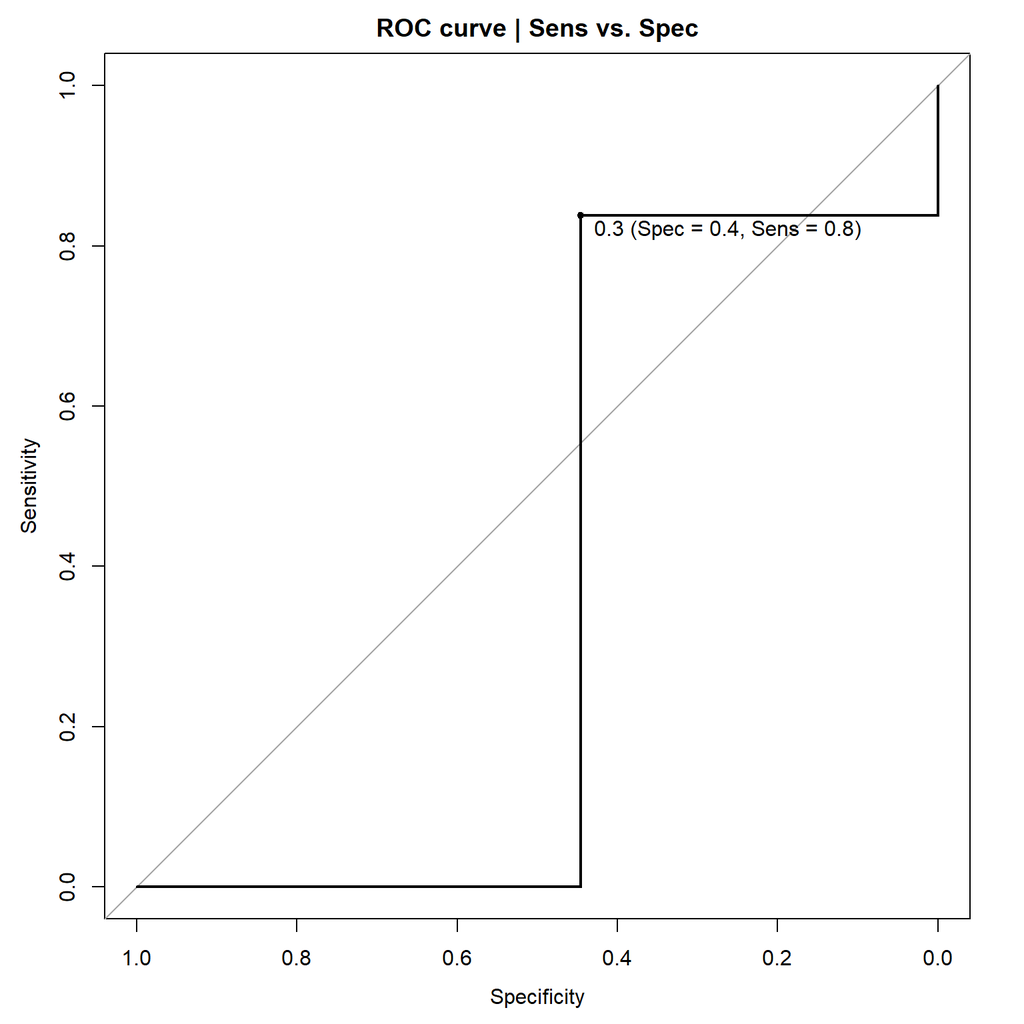

```r
pROC:::plot.roc(roc_check,
     print.thres = optimal_cutoff$threshold,
     type = "S",
     print.thres.pattern = "%.1f (Spec = %.1f, Sens = %.1f)",
     print.thres.cex = 1,
     legacy.axes = F,
     main = "ROC curve | Sens vs. Spec")
```

```r
dg$probs_check <- probs_check

dg$pred <- ifelse(test = dg$probs_check > optimal_cutoff$threshold,
                       yes = 1,
                       no = 0)

table(pred = dg$pred,
      ref = dg$diabetes) -> kq

kq <- kq[2:1, 2:1]

kq
```

```
    ref
pred   1   0
   1 222 256
   0  43 206
```

```r
library(epiR)
epiR:::epi.tests(kq, digits = 4)
```

```
          Outcome +    Outcome -      Total
Test +          222          256        478
Test -           43          206        249
Total           265          462        727

Point estimates and 95% CIs:
--------------------------------------------------------------
Apparent prevalence *                  0.6575 (0.6217, 0.6920)
True prevalence *                      0.3645 (0.3294, 0.4007)
Sensitivity *                          0.8377 (0.7877, 0.8800)
Specificity *                          0.4459 (0.4000, 0.4925)
Positive predictive value *            0.4644 (0.4190, 0.5103)
Negative predictive value *            0.8273 (0.7745, 0.8721)
Positive likelihood ratio              1.5119 (1.3715, 1.6666)
Negative likelihood ratio              0.3639 (0.2718, 0.4872)
False T+ proportion for true D- *      0.5541 (0.5075, 0.6000)
False T- proportion for true D+ *      0.1623 (0.1200, 0.2123)
False T+ proportion for T+ *           0.5356 (0.4897, 0.5810)
False T- proportion for T- *           0.1727 (0.1279, 0.2255)
Correctly classified proportion *      0.5887 (0.5520, 0.6248)
--------------------------------------------------------------
* Exact CIs
```

```r
library(caret)

caret::confusionMatrix(reference = factor(dg$diabetes,
                                          levels = c(1,0)), #thuc nghiem
                       data = factor(dg$pred,
                                       levels = c(1,0)),  #tien luong,
                       positive = "1",
                       mode = "everything")
```

```
Confusion Matrix and Statistics

          Reference
Prediction   1   0
         1 222 256
         0  43 206

               Accuracy : 0.5887
                 95% CI : (0.552, 0.6248)
    No Information Rate : 0.6355
    P-Value [Acc > NIR] : 0.9959

                  Kappa : 0.2421

 Mcnemar's Test P-Value : <2e-16

            Sensitivity : 0.8377
            Specificity : 0.4459
         Pos Pred Value : 0.4644
         Neg Pred Value : 0.8273
              Precision : 0.4644
                 Recall : 0.8377
                     F1 : 0.5976
             Prevalence : 0.3645
         Detection Rate : 0.3054
   Detection Prevalence : 0.6575
      Balanced Accuracy : 0.6418

       'Positive' Class : 1
```

# 7 Multiple logistic regression | Adjusted OR

Ta thực hiện model hồi quy đa biến, biến `age` là biến nền (covariate) hay là biến control, giúp hiệu chỉnh tốt hơn tác động của các biến bệnh học (béo phì, huyết áp, mang thai, di truyền).

```r
fit3 <- glm(diabetes ~ age +
              obesity +
              blood_pressure +
              pregnancies +
              diabetes_pedigree,
            data = dg,
            family = "binomial")

summary(fit3)
```

```
Call:
glm(formula = diabetes ~ age + obesity + blood_pressure + pregnancies +
    diabetes_pedigree, family = "binomial", data = dg)

Coefficients:
                   Estimate Std. Error z value     Pr(>|z|)
(Intercept)       -2.850431   0.540551  -5.273 0.0000001341 ***
age                0.021430   0.009898   2.165      0.03038 *
obesity            0.996226   0.182684   5.453 0.0000000495 ***
blood_pressure     0.003981   0.006998   0.569      0.56941
pregnancies        0.058847   0.030290   1.943      0.05204 .
diabetes_pedigree  0.656951   0.226933   2.895      0.00379 **
---
Signif. codes:  0 '***' 0.001 '**' 0.01 '*' 0.05 '.' 0.1 ' ' 1

(Dispersion parameter for binomial family taken to be 1)

    Null deviance: 953.78  on 726  degrees of freedom
Residual deviance: 874.88  on 721  degrees of freedom
AIC: 886.88

Number of Fisher Scoring iterations: 4
```

```r
# Adjusted odds ratios
OR <- exp(coef(fit3))

# 95% CI
CI <- exp(confint(fit3))

results_logistic <- data.frame(
  OR = OR,
  Lower_CI = CI[, 1],
  Upper_CI = CI[, 2],
  P_value = coef(summary(fit3))[, 4]
)

results_logistic
```

```
                         OR   Lower_CI  Upper_CI          P_value
(Intercept)       0.0578194 0.01972004 0.1645882 0.00000013406754
age               1.0216617 1.00214382 1.0418950 0.03038455311571
obesity           2.7080435 1.90233554 3.8967069 0.00000004945254
blood_pressure    1.0039894 0.99032852 1.0179146 0.56941068218263
pregnancies       1.0606125 0.99949469 1.1257345 0.05204469128808
diabetes_pedigree 1.9289020 1.24118492 3.0301278 0.00379261557026
```

```r
gtsummary:::tbl_regression(fit3,
                           exponentiate = T)
```

| **Characteristic** | **OR** | **95% CI** | **p-value** |
| --- | --- | --- | --- |
| Age | 1.02 | 1.00, 1.04 | 0.030 |
| obesity | 2.71 | 1.90, 3.90 | <0.001 |
| Diastolic blood pressure | 1.00 | 0.99, 1.02 | 0.6 |
| Number of pregnancies | 1.06 | 1.00, 1.13 | 0.052 |
| Diabetes pedigree function | 1.93 | 1.24, 3.03 | 0.004 |

Abbreviations: CI = Confidence Interval, OR = Odds Ratio

```r
library(car)
car:::vif(fit3)
```

```
              age           obesity    blood_pressure       pregnancies diabetes_pedigree
         2.193790          1.029225          1.080491          2.141583          1.008069
```

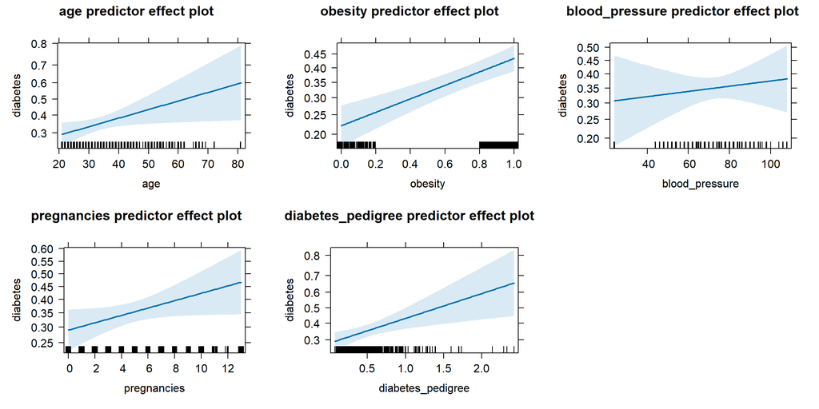

```r
library(effects)

plot(predictorEffects(fit3, ~ .))
```

# 8 Mediation analysis

Biến X tác động lên mediator M (biến trung gian) và sau đó biến mediator tác động lên biến Y. Thứ tự xuất hiện của biến trung gian là xuất hiện sau biến X.

```r
diabetes_med <- mediation_analysis(
  data = dg,
  exposure = obesity, # X
  mediator = glucose, # M
  outcome = diabetes, # Y
  covariates = c(age, blood_pressure, pregnancies, diabetes_pedigree),
  outcome_approach = logit,
  sims = 100,
  seed = 123
)

diabetes_med$table
```

| Effect | Estimate | 95% CI | p-value | Interpretation |
| --- | --- | --- | --- | --- |
| Total effect | 0.226 | 0.146 to 0.299 | <0.001 | Overall exposure-outcome association |
| Direct effect | 0.176 | 0.109 to 0.233 | <0.001 | Association not through the mediator |
| Indirect effect | 0.051 | 0.019 to 0.083 | <0.001 | Association through the mediator |
| Proportion mediated | 0.224 | 0.097 to 0.329 | <0.001 | Share of total effect through the mediator |

Effects are predicted probability differences from logistic outcome models.  
Comparison: obesity = 1 vs 0; mediator = Plasma glucose; outcome = diabetes. Bootstrap replicates = 100.  
Adjusted for Age, Diastolic blood pressure, Number of pregnancies, Diabetes pedigree function.  
Causal interpretation requires DAG-supported no-unmeasured-confounding and correct temporal-order assumptions.

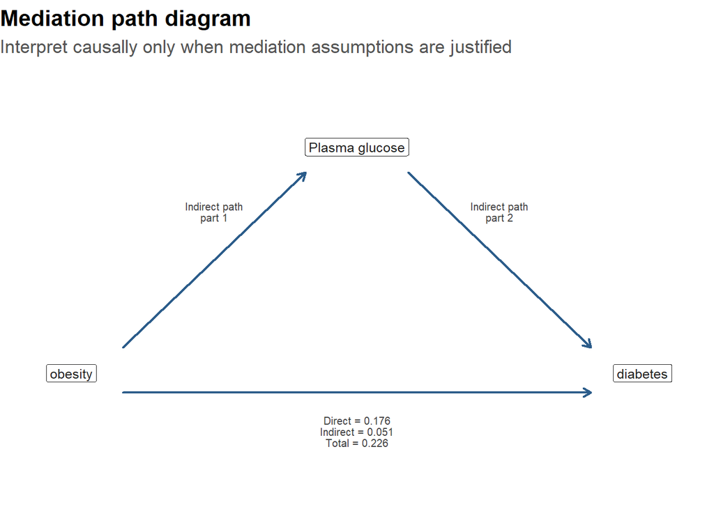

```r
plot_mediation(diabetes_med)
```

# 9 Confounder analysis

Confounder C (biến nhiễu) tác động lên cả biến X và biến Y. Thứ tự xuất hiện của biến nhiễu là xuất hiện trước biến X.

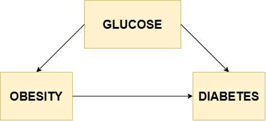

## 9.1 `diabetes` ~ `obesity` | confounder `glucose`

```r
fit_diabetes_obesity <- glm(diabetes ~ obesity,
            data = dg,
            family = "binomial")

summary(fit_diabetes_obesity)
```

```
Call:
glm(formula = diabetes ~ obesity, family = "binomial", data = dg)

Coefficients:
            Estimate Std. Error z value      Pr(>|z|)
(Intercept)  -1.2357     0.1479  -8.355       < 2e-16 ***
obesity       1.0067     0.1749   5.756 0.00000000862 ***
---
Signif. codes:  0 '***' 0.001 '**' 0.01 '*' 0.05 '.' 0.1 ' ' 1

(Dispersion parameter for binomial family taken to be 1)

    Null deviance: 953.78  on 726  degrees of freedom
Residual deviance: 918.07  on 725  degrees of freedom
AIC: 922.07

Number of Fisher Scoring iterations: 4
```

```r
fit_obesity_glucose <- glm(obesity ~ glucose,
            data = dg,
            family = "binomial")

summary(fit_obesity_glucose)
```

```
Call:
glm(formula = obesity ~ glucose, family = "binomial", data = dg)

Coefficients:
             Estimate Std. Error z value Pr(>|z|)
(Intercept) -0.437983   0.324376  -1.350  0.17694
glucose      0.008145   0.002561   3.181  0.00147 **
---
Signif. codes:  0 '***' 0.001 '**' 0.01 '*' 0.05 '.' 0.1 ' ' 1

(Dispersion parameter for binomial family taken to be 1)

    Null deviance: 950.39  on 726  degrees of freedom
Residual deviance: 939.95  on 725  degrees of freedom
AIC: 943.95

Number of Fisher Scoring iterations: 4
```

```r
fit_diabetes_glucose <- glm(diabetes ~ glucose,
            data = dg,
            family = "binomial")

summary(fit_obesity_glucose)
```

```
Call:
glm(formula = obesity ~ glucose, family = "binomial", data = dg)

Coefficients:
             Estimate Std. Error z value Pr(>|z|)
(Intercept) -0.437983   0.324376  -1.350  0.17694
glucose      0.008145   0.002561   3.181  0.00147 **
---
Signif. codes:  0 '***' 0.001 '**' 0.01 '*' 0.05 '.' 0.1 ' ' 1

(Dispersion parameter for binomial family taken to be 1)

    Null deviance: 950.39  on 726  degrees of freedom
Residual deviance: 939.95  on 725  degrees of freedom
AIC: 943.95

Number of Fisher Scoring iterations: 4
```

## 9.2 `diabetes` ~ `obesity` | confounder `age`

```r
fit_obesity_age <- glm(obesity ~ age,
            data = dg,
            family = "binomial")

summary(fit_obesity_age)
```

```
Call:
glm(formula = obesity ~ age, family = "binomial", data = dg)

Coefficients:
            Estimate Std. Error z value Pr(>|z|)
(Intercept) 0.257224   0.228648   1.125    0.261
age         0.009567   0.006547   1.461    0.144

(Dispersion parameter for binomial family taken to be 1)

    Null deviance: 950.39  on 726  degrees of freedom
Residual deviance: 948.22  on 725  degrees of freedom
AIC: 952.22

Number of Fisher Scoring iterations: 4
```

```r
fit_diabetes_age <- glm(diabetes ~ age,
            data = dg,
            family = "binomial")

summary(fit_diabetes_age)
```

```
Call:
glm(formula = diabetes ~ age, family = "binomial", data = dg)

Coefficients:
            Estimate Std. Error z value Pr(>|z|)
(Intercept) -1.79248    0.23457  -7.642 2.15e-14 ***
age          0.03659    0.00648   5.647 1.64e-08 ***
---
Signif. codes:  0 '***' 0.001 '**' 0.01 '*' 0.05 '.' 0.1 ' ' 1

(Dispersion parameter for binomial family taken to be 1)

    Null deviance: 953.78  on 726  degrees of freedom
Residual deviance: 920.58  on 725  degrees of freedom
AIC: 924.58

Number of Fisher Scoring iterations: 4
```

## 9.3 `diabetes` ~ `obesity` | confounder `race`

Tạo thêm cột `race`

```r
# set.seed(1)
race_ok <- sample(x = c("white", "black", "asia", "hispanic"),
                  size = nrow(dg),
                  replace = T,
                  prob = c(0.9, 0.5, 0.5, 0.5))

dg$race <- race_ok

table(dg$race)
```

```
    asia    black hispanic    white
     145      163      152      267
```

```r
fit_obesity_race <- glm(obesity ~ race,
            data = dg,
            family = "binomial")

summary(fit_obesity_race)
```

```
Call:
glm(formula = obesity ~ race, family = "binomial", data = dg)

Coefficients:
             Estimate Std. Error z value  Pr(>|z|)
(Intercept)    0.7035     0.1765   3.987 0.0000671 ***
raceblack      0.1119     0.2449   0.457     0.648
racehispanic  -0.1075     0.2447  -0.439     0.660
racewhite     -0.3477     0.2159  -1.611     0.107
---
Signif. codes:  0 '***' 0.001 '**' 0.01 '*' 0.05 '.' 0.1 ' ' 1

(Dispersion parameter for binomial family taken to be 1)

    Null deviance: 950.39  on 726  degrees of freedom
Residual deviance: 944.71  on 723  degrees of freedom
AIC: 952.71

Number of Fisher Scoring iterations: 4
```

```r
fit_diabetes_race <- glm(diabetes ~ race,
            data = dg,
            family = "binomial")

summary(fit_diabetes_race)
```

```
Call:
glm(formula = diabetes ~ race, family = "binomial", data = dg)

Coefficients:
             Estimate Std. Error z value Pr(>|z|)
(Intercept)  -0.58136    0.17316  -3.357 0.000787 ***
raceblack    -0.14883    0.24071  -0.618 0.536376
racehispanic  0.15391    0.23983   0.642 0.521038
racewhite     0.06853    0.21441   0.320 0.749247
---
Signif. codes:  0 '***' 0.001 '**' 0.01 '*' 0.05 '.' 0.1 ' ' 1

(Dispersion parameter for binomial family taken to be 1)

    Null deviance: 953.78  on 726  degrees of freedom
Residual deviance: 951.94  on 723  degrees of freedom
AIC: 959.94

Number of Fisher Scoring iterations: 4
```

## 9.4 Dùng lệnh rà soát nhanh confounder

```r
confounder_check <- identify_confounder(
  data = dg,
  outcome = diabetes, # Y
  exposure = obesity, # X
  potential_confounder = c("age",
                           "glucose",
                           "race"), # C
  approach = logit,
  method = both,
  format = gt
)

confounder_check$table
```

| Exposure | Potential confounder | Crude estimate | Adjusted estimate | MH estimate | % change model | % change MH | Confounder? | Interaction p | Effect modifier? | Decision | Recommendation |
| --- | --- | --- | --- | --- | --- | --- | --- | --- | --- | --- | --- |
| obesity | age | 2.737 | 2.734 | 2.500 | 0.09 | 8.65 | No | 0.183 | No | No evidence | No clear statistical evidence to include age as a confounder. |
| obesity | glucose | 2.737 | 2.586 | 2.373 | 5.52 | 13.28 | Yes | 0.355 | No | Confounder | Adjust for glucose. |
| obesity | race | 2.737 | 2.806 | 2.794 | 2.53 | 2.10 | No | 0.426 | No | No evidence | No clear statistical evidence to include race as a confounder. |

Outcome: diabetes. For each exposure E and potential confounder C, models tested: diabetes ~ E; diabetes ~ E + C; and interaction screen: diabetes ~ E + C + E:C (OR (95% CI) scale).  
Screening aid only; use DAGs, subject-matter knowledge, and study design to decide confounding and effect modification.

# 10 Moderator analysis

Biến điều tiết Z (medorator) có tác dụng điều chỉnh tác động (effect) của biến X lên biến Y, bản chất thể hiện qua ý nghĩa thống kê của biến tương tác giữa X và Z.

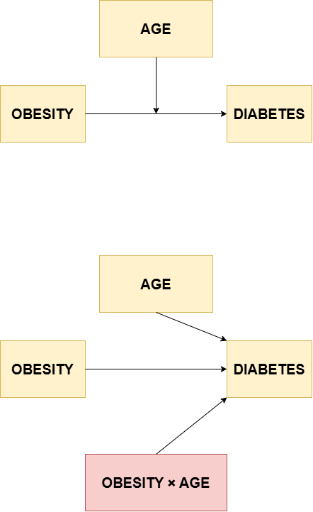

```r
mod1 <- glm(diabetes ~ obesity * age,
            data = dg,
            family = "binomial")

summary(mod1)
```

```
Call:
glm(formula = diabetes ~ obesity * age, family = "binomial",
    data = dg)

Coefficients:
            Estimate Std. Error z value Pr(>|z|)
(Intercept) -2.91164    0.43834  -6.642 3.09e-11 ***
obesity      1.65612    0.52529   3.153  0.00162 **
age          0.04895    0.01147   4.266 1.99e-05 ***
obesity:age -0.01864    0.01404  -1.328  0.18411
---
Signif. codes:  0 '***' 0.001 '**' 0.01 '*' 0.05 '.' 0.1 ' ' 1

(Dispersion parameter for binomial family taken to be 1)

    Null deviance: 953.78  on 726  degrees of freedom
Residual deviance: 884.88  on 723  degrees of freedom
AIC: 892.88

Number of Fisher Scoring iterations: 4
```

```r
dg$obesity_age <- dg$obesity * dg$age

mod2 <- glm(diabetes ~ obesity + age + obesity_age,
            data = dg,
            family = "binomial")

summary(mod2)
```

```
Call:
glm(formula = diabetes ~ obesity + age + obesity_age, family = "binomial",
    data = dg)

Coefficients:
            Estimate Std. Error z value Pr(>|z|)
(Intercept) -2.91164    0.43834  -6.642 3.09e-11 ***
obesity      1.65612    0.52529   3.153  0.00162 **
age          0.04895    0.01147   4.266 1.99e-05 ***
obesity_age -0.01864    0.01404  -1.328  0.18411
---
Signif. codes:  0 '***' 0.001 '**' 0.01 '*' 0.05 '.' 0.1 ' ' 1

(Dispersion parameter for binomial family taken to be 1)

    Null deviance: 953.78  on 726  degrees of freedom
Residual deviance: 884.88  on 723  degrees of freedom
AIC: 892.88

Number of Fisher Scoring iterations: 4
```

```r
library(stargazer)

stargazer(mod1, mod2,
          type = "text")
```

```
==============================================
                      Dependent variable:
                  ----------------------------
                            diabetes
                       (1)            (2)
----------------------------------------------
obesity              1.656***      1.656***
                     (0.525)        (0.525)

age                  0.049***      0.049***
                     (0.011)        (0.011)

obesity:age           -0.019
                     (0.014)

obesity_age                         -0.019
                                    (0.014)

Constant            -2.912***      -2.912***
                     (0.438)        (0.438)

----------------------------------------------
Observations           727            727
Log Likelihood       -442.441      -442.441
Akaike Inf. Crit.    892.882        892.882
==============================================
Note:              *p<0.1; **p<0.05; ***p<0.01
```

## 10.1 Interaction

```r
interaction_check <- gtregression:::interaction_models(
  data = dg,
  outcome = diabetes,
  exposure = obesity,
  effect_modifier = age,
  covariates = c("race", "glucose"),
  approach = logit,
  test = LRT,
  format = gt
)

interaction_check$table
```

Interaction screening

| Outcome | Exposure | Effect modifier tested | Adjustment covariates | Approach | Test | p-value | Alpha | Interaction? | Decision | Interpretation |
| --- | --- | --- | --- | --- | --- | --- | --- | --- | --- | --- |
| diabetes | obesity | age | race, glucose | logit | Likelihood Ratio Test | 0.116 | 0.050 | No | No interaction | No statistical evidence of interaction between obesity and age at alpha = 0.05. |

Models tested: diabetes ~ obesity + age + race + glucose; diabetes ~ obesity + age + race + glucose + obesity:age.  
Screening aid only; interaction decisions should be interpreted with subject-matter knowledge, study design, and stratum-specific estimates.

# 11 Tài liệu tham khảo

1. Homogeneity of Variance https://methods.sagepub.com/ency/edvol/encyc-of-research-design/chpt/homogeneity-variance
2. Package `interactions` https://interactions.jacob-long.com/articles/interactions
3. An introduction to ROC analysis https://longliveturtle.github.io/water/p1.pdf
4. Logistic Regression Details Pt1: Coefficients https://www.youtube.com/watch?v=vN5cNN2-HWE
5. Logistic Regression https://stats.oarc.ucla.edu/r/dae/logit-regression/
6. SOGA-R https://www.geo.fu-berlin.de/en/v/soga-r/Basics-of-statistics/Logistic-Regression/Logistic-Regression-in-R---An-Example/index.html
7. Logistic Regression https://statsandr.com/blog/binary-logistic-regression-in-r/
8. Cách tính Odds Ratio https://www.medcalc.org/en/calc/odds_ratio.php
9. Diễn giải hệ số OR https://stackoverflow.com/questions/41384075/r-calculate-and-interpret-odds-ratio-in-logistic-regression
10. Logistic Regression https://bookdown.org/nhanhocumc/biodata-r/logisticr.html
11. Logistic Regression https://argoshare.is.ed.ac.uk/healthyr_book/binary-logistic-regression.html
12. Phân tích Mediation https://cran.r-project.org/web/packages/gtregression/vignettes/causal-mediation.html
13. Phân tích Confounder https://cran.r-project.org/web/packages/gtregression/vignettes/confounding-interaction.html